← Back to R & Statistics

# Mental Health

### Background

Mental health is a significant challenge among youth today. According to the CDC (Centers for Disease Control and Prevention), suicide is the second leading cause of death for individuals aged 10 to 24, and nearly 20% of teenagers are diagnosed with a mental health disorder each year (source link) . With the suicide rate rising among youth, we wonder what contributes the most to this growing problem in our century. To first try to understand what contributes to this increasing prevalence of mental illness among teens, we found a sample dataset on Kaggle about mental health that is described as follows:*” This dataset is designed to analyze mental health patterns in teenagers, focusing on stress levels using anonymized data from social media activity, surveys, and wearable devices. It consists of 5,000 entries and 11 columns, each capturing different aspects of the user’s daily behavior and well-being. The goal is to detect correlations between factors like social media usage, physical activity, sleep patterns, and stress levels. This dataset can be useful for research on adolescent mental health, early stress detection, and preventive care.”*

### Influence of exercise on stress level(score measured by device)

In this part of our analysis, we aim to determine whether average exercise hours have a significant impact on stress levels among teenagers. To explore this relationship, we will use a simple linear regression to test if exercise meaningfully predicts stress

#### Dataset Used

```r
library(tidyverse)
library(pander)
library(DT)

# Load dataset
mentalhealth <- read_csv("../Data/mental_health_analysis.csv")

mhealthlm <- mentalhealth |>
  select(Exercise_Hours, Wearable_Stress_Score)

datatable(mhealthlm)
```

|  | Exercise_Hours | Wearable_Stress_Score |
| --- | --- | --- |
| 1 | 2.458001257 | 0.288962247 |
| 2 | 0.392094761 | 0.409446165 |
| 3 | 0.52011947 | 0.423837485 |
| 4 | 1.022629619 | 0.666020828 |
| 5 | 1.225462167 | 0.928060356 |
| 6 | 1.046108433 | 0.070586489 |
| 7 | 2.290941098 | 0.953353593 |
| 8 | 0.290854178 | 0.910201284 |
| 9 | 1.053651059 | 0.1177323 |
| 10 | 2.511719999 | 0.183585031 |

[output cut: 4990 more lines]

#### The model: Simple Linear Regression

The true regression model assumed by a regression analysis is given by

$$\underbrace{Y_i}_\text{Stress level} =
\overbrace{\beta_0}^\text{y-int} + \overbrace{\beta_1}^\text{slope}
\underbrace{X_i}_\text{exercise Hour} + \epsilon_i \quad \text{where} \
\epsilon_i \sim N(0, \sigma^2)$$

The estimated regression line is given by:

$$\underbrace{\hat{Y}_i}_\text{stress level} =
\overbrace{b_0}^\text{est. y-int} + \overbrace{b_1}^\text{est. slope}
\underbrace{X_i}_\text{exercise Hour}$$

#### Analysis

##### Hypthesis

$$\left.\begin{array}{ll}
H_0: \beta_1 = 0 \\
H_a: \beta_1 \neq 0
\end{array}
\right\} \ \text{Slope Hypotheses}$$

$$\left.\begin{array}{ll}
H_0: \beta_0 = 0 \\
H_a: \beta_0 \neq 0
\end{array}
\right\} \ \text{Intercept Hypotheses}$$

##### Test

*Test Result**

```r
mhealth.lm <- lm(Wearable_Stress_Score ~ Exercise_Hours , data = mhealthlm)
summary(mhealth.lm) |> pander()
```

|  | Estimate | Std. Error | t value | Pr(>\|t\|) |
| --- | --- | --- | --- | --- |
| **(Intercept)** | 0.5012 | 0.008134 | 61.63 | 0 |
| **Exercise_Hours** | -0.003083 | 0.00469 | -0.6573 | 0.511 |

Fitting linear model: Wearable_Stress_Score ~ Exercise_Hours

| Observations | Residual Std. Error | $R^2$ | Adjusted $R^2$ |
| --- | --- | --- | --- |
| 5000 | 0.2898 | 8.644e-05 | -0.0001136 |

*Interpetation*

Based on the regression results, average exercise hours do not have a statistically significant effect on stress levels among teenagers in this dataset:

The p-value (0.511) for Exercise_Hours is much greater than 0.05, so we fail to reject the null hypothesis — there is no significant evidence that exercise hours predict stress level.

The coefficient (-0.00308) is very small and suggests a slight decrease in stress with more exercise, but it’s not statistically meaningful.

#### Visualization

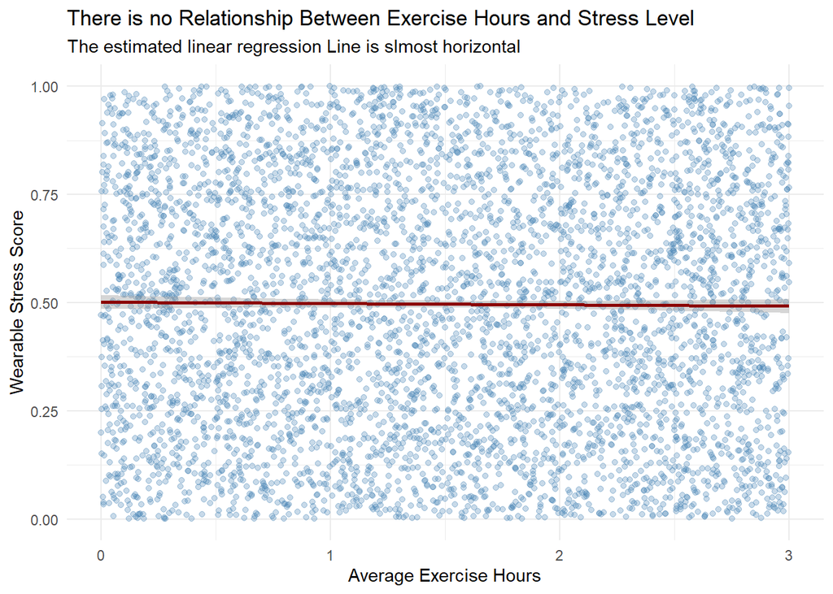

```r
library(ggplot2)

# Assuming your data is in a dataframe called `df`
ggplot(mhealthlm, aes(x = Exercise_Hours, y = Wearable_Stress_Score)) +
  geom_point(alpha = 0.3, color = "steelblue") +  # scatter plot
  geom_smooth(method = "lm", color = "darkred", se = TRUE) +  # regression line
  labs(
    title = "There is no Relationship Between Exercise Hours and Stress Level",
    subtitle = "The estimated linear regression Line is slmost horizontal",
    x = "Average Exercise Hours",
    y = "Wearable Stress Score"
  ) +
  theme_minimal()
```

### Influence of social media hours on stress level(score measured by device)

In this part of our analysis, we aim to determine whether average screen time has a significant impact on stress levels among teenagers. To explore this relationship, we will use a simple linear regression to test if screen time meaningfully predicts stress.

#### Dataset

```r
socialhealthlm <- mentalhealth |>
  select(Social_Media_Hours, Wearable_Stress_Score)

datatable(socialhealthlm)
```

|  | Social_Media_Hours | Wearable_Stress_Score |
| --- | --- | --- |
| 1 | 9.654486346 | 0.288962247 |
| 2 | 9.158143482 | 0.409446165 |
| 3 | 5.028755201 | 0.423837485 |
| 4 | 7.951102825 | 0.666020828 |
| 5 | 1.357458531 | 0.928060356 |
| 6 | 9.774381842 | 0.070586489 |
| 7 | 9.64353234 | 0.953353593 |
| 8 | 1.637289579 | 0.910201284 |
| 9 | 2.994231248 | 0.1177323 |
| 10 | 1.001549975 | 0.183585031 |

[output cut: 4990 more lines]

#### The Model

The true regression model assumed by a regression analysis is given by

$$\underbrace{Y_i}_\text{Stress level} =
\overbrace{\beta_0}^\text{y-int} + \overbrace{\beta_1}^\text{slope}
\underbrace{X_i}_\text{Average Social media Hour} + \epsilon_i \quad
\text{where} \ \epsilon_i \sim N(0, \sigma^2)$$

The estimated regression line is given by:

$$\underbrace{\hat{Y}_i}_\text{stress level} = \overbrace{b_0}^\text{est.
y-int} + \overbrace{b_1}^\text{est. slope}
\underbrace{X_i}_\text{Average Social Media Hour}$$

#### Analysis

##### hyptheses

$$\left.\begin{array}{ll}
H_0: \beta_1 = 0 \\
H_a: \beta_1 \neq 0
\end{array}
\right\} \ \text{Slope Hypotheses}$$

$$\left.\begin{array}{ll}
H_0: \beta_0 = 0 \\
H_a: \beta_0 \neq 0
\end{array}
\right\} \ \text{Intercept Hypotheses}$$

##### Test

*Test Result**

```r
socialhealth.lm <- lm(Wearable_Stress_Score ~ Social_Media_Hours , data = socialhealthlm)
summary(socialhealth.lm) |> pander()
```

|  | Estimate | Std. Error | t value | Pr(>\|t\|) |
| --- | --- | --- | --- | --- |
| **(Intercept)** | 0.4868 | 0.008182 | 59.5 | 0 |
| **Social_Media_Hours** | 0.001981 | 0.001436 | 1.379 | 0.1679 |

Fitting linear model: Wearable_Stress_Score ~ Social_Media_Hours

| Observations | Residual Std. Error | $R^2$ | Adjusted $R^2$ |
| --- | --- | --- | --- |
| 5000 | 0.2897 | 0.0003805 | 0.0001805 |

*Interpretation*

The analysis suggests that social media usage is not a significant predictor of stress levels among teenagers in this dataset. Although the coefficient for Social_Media_Hours is positive (suggesting a slight increase in stress with more screen time), the p-value of 0.1679 means this relationship is not statistically significant.

The y-intercept is 0.4868. According to this model, an individual who spends zero hours on social media would have an average predicted stress level score of approximately 0.4868. This intercept mainly acts as a baseline in our model, showing the starting value of the predicted response when social media use is not considered.

##### Visualisation

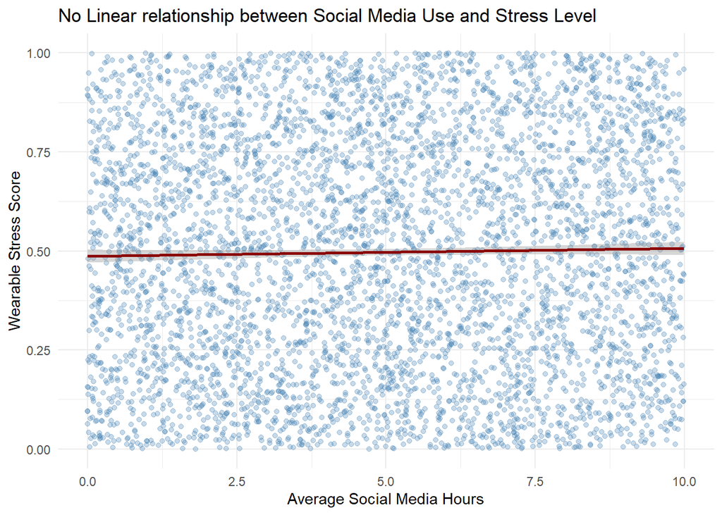

```r
library(ggplot2)

# Assuming your data frame is called df
ggplot(socialhealthlm, aes(x = Social_Media_Hours, y = Wearable_Stress_Score)) +
  geom_point(alpha = 0.3, color = "steelblue") +  # dots for each observation
  geom_smooth(method = "lm", color = "darkred", se = TRUE) +  # regression line with confidence interval
  labs(
    title = "No Linear relationship between Social Media Use and Stress Level",
    x = "Average Social Media Hours",
    y = "Wearable Stress Score"
  ) +
  theme_minimal()
```

### Influence of Sleep hour on stress level(score measured by device)

In this part of our analysis, we aim to determine whether average sleep hours have a significant impact on stress levels among teenagers. To explore this relationship, we will use a simple linear regression to test if sleep duration meaningfully predicts stress.

#### Dataset

```r
sleephealthlm <- mentalhealth |>
  select(Sleep_Hours, Wearable_Stress_Score)

datatable(sleephealthlm)
```

|  | Sleep_Hours | Wearable_Stress_Score |
| --- | --- | --- |
| 1 | 5.198925522 | 0.288962247 |
| 2 | 8.866096662 | 0.409446165 |
| 3 | 4.94309483 | 0.423837485 |
| 4 | 5.262773303 | 0.666020828 |
| 5 | 6.196080351 | 0.928060356 |
| 6 | 9.282089175 | 0.070586489 |
| 7 | 4.790720012 | 0.953353593 |
| 8 | 4.733405157 | 0.910201284 |
| 9 | 6.96384993 | 0.1177323 |
| 10 | 5.658463247 | 0.183585031 |

[output cut: 4990 more lines]

#### The Model

The true regression model assumed by a regression analysis is given by

$$\underbrace{Y_i}_\text{Stress level} =
\overbrace{\beta_0}^\text{y-int} + \overbrace{\beta_1}^\text{slope}
\underbrace{X_i}_\text{Average Sleep hour} + \epsilon_i \quad
\text{where} \ \epsilon_i \sim N(0, \sigma^2)$$

The estimated regression line is given by:

$$\underbrace{\hat{Y}_i}_\text{stress level} = \overbrace{b_0}^\text{est.
y-int} + \overbrace{b_1}^\text{est. slope}
\underbrace{X_i}_\text{Average Sleep Hour}$$

#### Analysis

##### hyptheses

$$\left.\begin{array}{ll}
H_0: \beta_1 = 0 \\
H_a: \beta_1 \neq 0
\end{array}
\right\} \ \text{Slope Hypotheses}$$

$$\left.\begin{array}{ll}
H_0: \beta_0 = 0 \\
H_a: \beta_0 \neq 0
\end{array}
\right\} \ \text{Intercept Hypotheses}$$

##### Test

*Test Result**

```r
sleephealth.lm <- lm(Wearable_Stress_Score ~ Sleep_Hours , data = sleephealthlm)
summary(sleephealth.lm) |> pander()
```

|  | Estimate | Std. Error | t value | Pr(>\|t\|) |
| --- | --- | --- | --- | --- |
| **(Intercept)** | 0.5106 | 0.01729 | 29.54 | 7.033e-177 |
| **Sleep_Hours** | -0.001986 | 0.00238 | -0.8345 | 0.404 |

Fitting linear model: Wearable_Stress_Score ~ Sleep_Hours

| Observations | Residual Std. Error | $R^2$ | Adjusted $R^2$ |
| --- | --- | --- | --- |
| 5000 | 0.2898 | 0.0001393 | -6.074e-05 |

*Interpretation*

The analysis indicates that average sleep hours do not have a statistically significant impact on wearable stress scores in this sample of teenagers. While the coefficient is negative — hinting that more sleep might reduce stress — the p-value of 0.404 tells us that this effect is not strong enough to be considered significant.

There is no evidence from this model to suggest that differences in sleep duration are meaningfully associated with changes in stress levels.

The y-intercept is 0.5106. This means that, according to our regression model, someone who gets zero hours of sleep would have an average predicted response value of approximately 0.5106. However, this interpretation may not be practical, since zero hours of sleep isn’t realistic for most people. Therefore, the intercept mainly serves as a baseline or starting point for the model rather than a meaningful prediction.

##### Visualisation

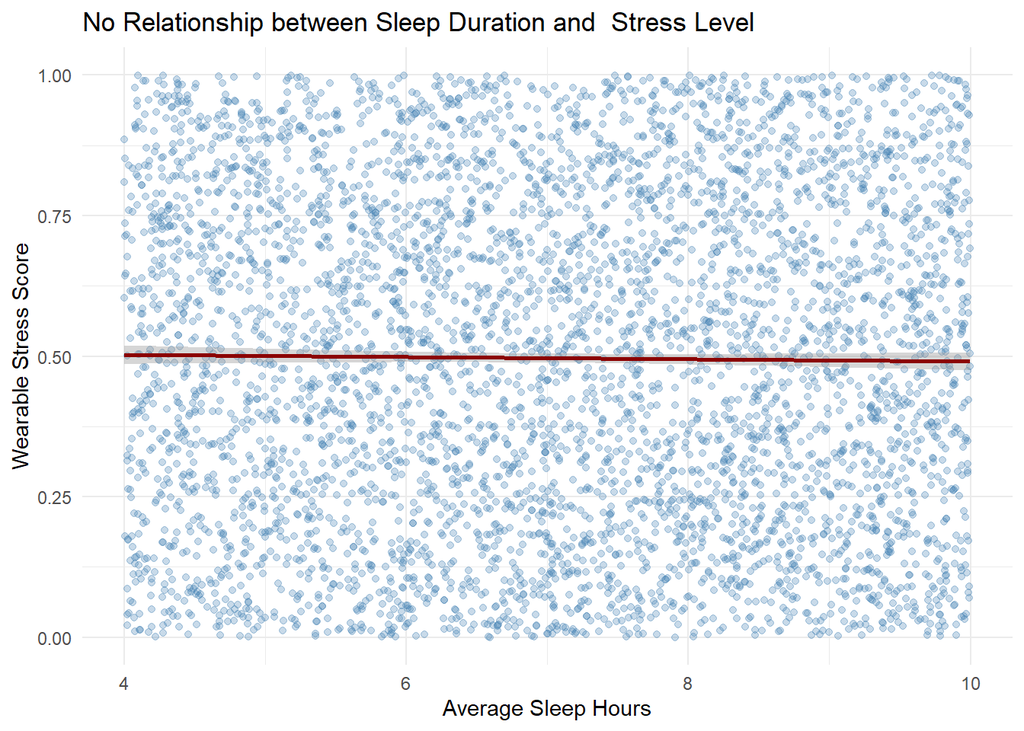

```r
library(ggplot2)

ggplot(sleephealthlm, aes(x = Sleep_Hours, y = Wearable_Stress_Score)) +
  geom_point(alpha = 0.3, color = "steelblue") +  # scatter plot
  geom_smooth(method = "lm", color = "darkred", se = TRUE) +  # regression line
  labs(
    title = "No Relationship between Sleep Duration and  Stress Level",
    x = "Average Sleep Hours",
    y = "Wearable Stress Score"
  ) +
  theme_minimal()
```

### Influence of Average Screen Time on stress level(score measured by device)

#### Dataset

```r
screenhealthlm <- mentalhealth |>
  select(Screen_Time_Hours, Wearable_Stress_Score)

datatable(screenhealthlm)
```

|  | Screen_Time_Hours | Wearable_Stress_Score |
| --- | --- | --- |
| 1 | 8.158188998 | 0.288962247 |
| 2 | 5.151993467 | 0.409446165 |
| 3 | 9.209325483 | 0.423837485 |
| 4 | 9.823657952 | 0.666020828 |
| 5 | 11.33898971 | 0.928060356 |
| 6 | 5.677746722 | 0.070586489 |
| 7 | 8.86016736 | 0.953353593 |
| 8 | 8.026162769 | 0.910201284 |
| 9 | 7.252060695 | 0.1177323 |
| 10 | 10.90416474 | 0.183585031 |

[output cut: 4990 more lines]

#### Model

The true regression model assumed by a regression analysis is given by

$$\underbrace{Y_i}_\text{Stress Level} =
\overbrace{\beta_0}^\text{y-int} + \overbrace{\beta_1}^\text{slope}
\underbrace{X_i}_\text{Average Screen time} + \epsilon_i \quad
\text{where} \ \epsilon_i \sim N(0, \sigma^2)$$

The estimated regression line is given by:

$$\underbrace{\hat{Y}_i}_\text{stress level} = \overbrace{b_0}^\text{est.
y-int} + \overbrace{b_1}^\text{est. slope}
\underbrace{X_i}_\text{Average Screen Time}$$

#### Analysis

##### hyptheses

$$\left.\begin{array}{ll}
H_0: \beta_1 = 0 \\
H_a: \beta_1 \neq 0
\end{array}
\right\} \ \text{Slope Hypotheses}$$

$$\left.\begin{array}{ll}
H_0: \beta_0 = 0 \\
H_a: \beta_0 \neq 0
\end{array}
\right\} \ \text{Intercept Hypotheses}$$

```r
screenhealth.lm <- lm(Wearable_Stress_Score ~ Screen_Time_Hours , data = screenhealthlm)
summary(screenhealth.lm) |> pander()
```

|  | Estimate | Std. Error | t value | Pr(>\|t\|) |
| --- | --- | --- | --- | --- |
| **(Intercept)** | 0.5043 | 0.01085 | 46.47 | 0 |
| **Screen_Time_Hours** | -0.00108 | 0.001421 | -0.7599 | 0.4473 |

Fitting linear model: Wearable_Stress_Score ~ Screen_Time_Hours

| Observations | Residual Std. Error | $R^2$ | Adjusted $R^2$ |
| --- | --- | --- | --- |
| 5000 | 0.2898 | 0.0001155 | -8.453e-05 |

This analysis shows that average screen time is not a significant predictor of wearable stress scores among teenagers. Although the coefficient is slightly negative (indicating a potential decrease in stress with more screen time), the p-value of 0.4473 shows that this result is not statistically meaningful.

The y-intercept is 0.5043. According to our regression model, someone who spends zero hours on screen time is predicted to have an average stress score of approximately 0.5043. This intercept gives us a baseline or starting point, indicating the average predicted response when screen time isn’t considered.

### Partial Conclusion

Across multiple simple linear regression models testing the effects of exercise hours, sleep duration, social media usage, and screen time on stress levels in teenagers, none of the predictors showed a statistically significant relationship with wearable stress scores. While a few variables, such as sleep and screen time, showed slight negative trends (indicating a potential decrease in stress), the p-values were all well above 0.05 indicating that these variables explained very little variation in stress.

These findings suggest that stress levels among teenagers are likely influenced by more complex or additional factors beyond these single behavioral measures. Further analysis using multiple regression or including other variables like gender, academic performance, suport system, or mental health history may provide more meaningful insights.

As a next step, we shift our focus to exploring whether male teenagers experience higher average stress levels than females, using the available data to compare stress across gender groups.

### Stress Level and Gender among Teenagers

While earlier analysis showed no significant relationship between individual behaviors (such as exercise, sleep, screen time, or social media use) and teenage stress levels, it remains important to explore whether stress varies across demographic groups. In this section, we examine whether there is a difference in average stress levels between male and female teenagers. Specifically, we aim to determine if male teenagers report higher average stress compared to females using a two-sample t-test.

#### Dataset Used

```r
genderhealthlm <- mentalhealth |>
  select(Gender, Wearable_Stress_Score) |>
  mutate(Wearable_Stress_Score = round(Wearable_Stress_Score, 3)) # limit the number of decimal number to 3

datatable(genderhealthlm)
```

|  | Gender | Wearable_Stress_Score |
| --- | --- | --- |
| 1 | F | 0.289 |
| 2 | M | 0.409 |
| 3 | M | 0.424 |
| 4 | F | 0.666 |
| 5 | F | 0.928 |
| 6 | M | 0.071 |
| 7 | F | 0.953 |
| 8 | F | 0.91 |
| 9 | M | 0.118 |
| 10 | M | 0.184 |

[output cut: 4990 more lines]

#### The Model: Independent Samples t Test

##### Hypotheses

$$H_0: \mu_\text{Male} - \mu_\text{Female} = 0$$

$\mu$ stands for *Average Stress Level Score*

significance level is $\alpha$ = 0.05

#### Analysis

##### Test Result

```r
t.test(Wearable_Stress_Score ~ Gender  ,data = genderhealthlm, mu = 0, alternative = "greater", conf.level = 0.95) |> pander()
```

Welch Two Sample t-test: `Wearable_Stress_Score` by `Gender` (continued below)

| Test statistic | df | P value | Alternative hypothesis | mean in group F |
| --- | --- | --- | --- | --- |
| 0.7372 | 4984 | 0.2305 | greater | 0.4996 |

| mean in group M |
| --- |
| 0.4936 |

##### Interpretation

Based on the results, there is no statistically significant evidence (p = 0.2305) to conclude that female teenagers have higher average stress levels compared to males. Although the observed mean stress level is slightly higher for females, this difference isn’t significant enough statistically to support a meaningful difference.

In summary, this analysis does not support the claim that either gender experiences significantly higher stress levels on average within this dataset.

#### Visualization

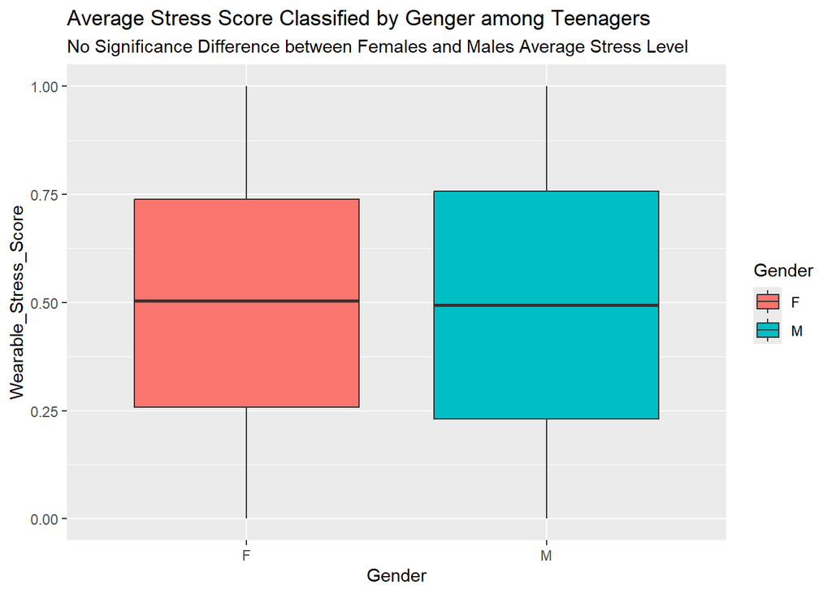

```r
ggplot(data = genderhealthlm,
       aes(x = Gender, y = Wearable_Stress_Score, fill = Gender))+
  geom_boxplot()+
  labs(
    title = "Average Stress Score Classified by Genger among Teenagers",
    subtitle = "No Significance Difference between Females and Males Average Stress Level"
  )
```

This visualization aligns with the statistical analysis, reinforcing that there isn’t a meaningful difference in stress levels between male and female teenagers based on this dataset.

```r
tapply(genderhealthlm$Wearable_Stress_Score, genderhealthlm$Gender, summary) |> pander(caption = "Data Description Based on Gender")
```

- **F**:

  | Min. | 1st Qu. | Median | Mean | 3rd Qu. | Max. |
  | --- | --- | --- | --- | --- | --- |
  | 0 | 0.258 | 0.504 | 0.4996 | 0.739 | 1 |

- **M**:

  | Min. | 1st Qu. | Median | Mean | 3rd Qu. | Max. |
  | --- | --- | --- | --- | --- | --- |
  | 0 | 0.231 | 0.4935 | 0.4936 | 0.7572 | 1 |

#### Check requirements for our t test

The test is only appropriate when both of the following are satisfied.

- Both samples are representative of the population. (Simple random samples are the best way to do this.)
- The sampling distribution of the difference of the sample means () can be assumed to be normal. (This is a safe assumption when the sample size of each group is 30 or greater or when the population data from each group can be assumed to be normal with a Q-Q Plot.)

```r
library(car)

table(genderhealthlm$Gender) |> pander( Caption = "Sample size for Each Group")
```

| F | M |
| --- | --- |
| 2528 | 2472 |

```r
# Separate the data by Gender
females <- subset(genderhealthlm, Gender == "F")
males <- subset(genderhealthlm, Gender == "M")

# QQ-plots side-by-side
par(mfrow = c(1,2))
qqPlot(females$Wearable_Stress_Score,
       main = "QQ-plot of Female Teenagers",
       ylab = "Wearable Stress Score",
       pch = 19)
```

```
## [1] 554 940
```

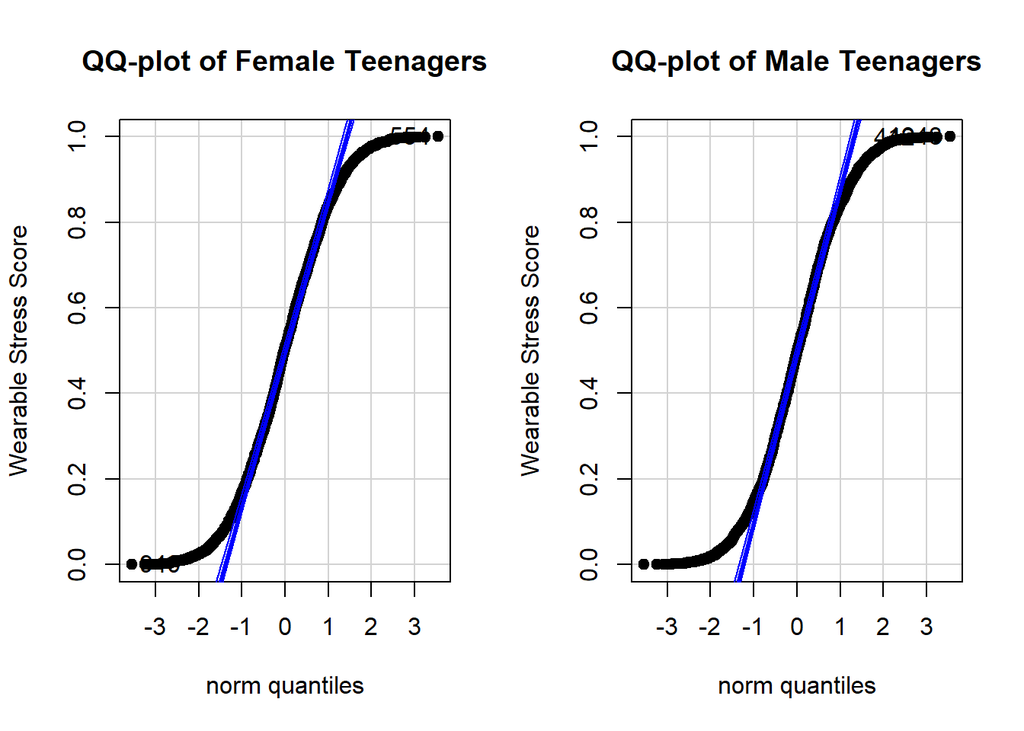

```
## [1] 1943  442
```

```r
qqPlot(males$Wearable_Stress_Score,
       main = "QQ-plot of Male Teenagers",
       ylab = "Wearable Stress Score",
       pch = 19)
```

```r
par(mfrow=c(1,1))  # Reset the layout
```

*Worth Knowing:* *After analyzing the data, we noticed it appears to be simulated because it follows a perfect uniform distribution, which rarely happens with real data. Therefore, our conclusions can’t be applied to real-world situations.*

### Final Thoughts

Overall, this study did not find significant relationships between common behavioral factors—such as exercise hours, sleep duration, screen time, or social media use—and wearable stress levels among teenagers. Additionally, the analysis found no statistically meaningful difference in average stress between male and female teenagers. Given these findings, it’s likely that teen stress levels are influenced by more complex or multiple interacting factors beyond those explored here. Future studies might consider examining psychological factors, social interactions, academic pressures, or combinations of various influences to gain deeper insight into teenage stress.